# Analysis of severe weather events across the USA

Joao Clemencio

22 July 2015

This is an analysis of the Storm Data dataset.

The questions to be addressed are:

1. Across the United States, which types of events (as indicated in the EVTYPE variable) are most harmful with respect to population health?
2. Across the United States, which types of events have the greatest economic consequences?

# Data Processing

## Download the data

```r
if(!file.exists('StormData.csv.bz2')) {
  file = 'https://d396qusza40orc.cloudfront.net/repdata%2Fdata%2FStormData.csv.bz2'
  download.file(file, destfile = 'StormData.csv.bz2')
}

storm.data = read.csv('StormData.csv.bz2', stringsAsFactors = FALSE)
storm.data = storm.data %>% tbl_df

storm.data
```

```
## Source: local data frame [902,297 x 37]
##
##    STATE__           BGN_DATE BGN_TIME TIME_ZONE COUNTY COUNTYNAME STATE
## 1        1  4/18/1950 0:00:00     0130       CST     97     MOBILE    AL
## 2        1  4/18/1950 0:00:00     0145       CST      3    BALDWIN    AL
## 3        1  2/20/1951 0:00:00     1600       CST     57    FAYETTE    AL
## 4        1   6/8/1951 0:00:00     0900       CST     89    MADISON    AL
## 5        1 11/15/1951 0:00:00     1500       CST     43    CULLMAN    AL
## 6        1 11/15/1951 0:00:00     2000       CST     77 LAUDERDALE    AL
## 7        1 11/16/1951 0:00:00     0100       CST      9     BLOUNT    AL
## 8        1  1/22/1952 0:00:00     0900       CST    123 TALLAPOOSA    AL
## 9        1  2/13/1952 0:00:00     2000       CST    125 TUSCALOOSA    AL
## 10       1  2/13/1952 0:00:00     2000       CST     57    FAYETTE    AL
## ..     ...                ...      ...       ...    ...        ...   ...
## Variables not shown: EVTYPE (chr), BGN_RANGE (dbl), BGN_AZI (chr),
##   BGN_LOCATI (chr), END_DATE (chr), END_TIME (chr), COUNTY_END (dbl),
##   COUNTYENDN (lgl), END_RANGE (dbl), END_AZI (chr), END_LOCATI (chr),
##   LENGTH (dbl), WIDTH (dbl), F (int), MAG (dbl), FATALITIES (dbl),
##   INJURIES (dbl), PROPDMG (dbl), PROPDMGEXP (chr), CROPDMG (dbl),
##   CROPDMGEXP (chr), WFO (chr), STATEOFFIC (chr), ZONENAMES (chr), LATITUDE
##   (dbl), LONGITUDE (dbl), LATITUDE_E (dbl), LONGITUDE_ (dbl), REMARKS
##   (chr), REFNUM (dbl)
```

The code above downloads and extracts the data to be processed. [Download the Storm Data Documentation here.](https://d396qusza40orc.cloudfront.net/repdata%2Fpeer2_doc%2Fpd01016005curr.pdf)

## Data Cleansing

There is some detailed information about the storm data csv in [this docx file](http://www1.ncdc.noaa.gov/pub/data/swdi/stormevents/csvfiles/Storm-Data-Export-Format.docx).

Only a few columns are required to answer the proposed questions:

- EVTYPE - Since we want to address each event type separately
- FATALITIES and INJURIES - to address question 1 regarding population health
- PROPDMG, PROPDMGEXP, CROPDMG and CROPDMGEXP - to address question 2 regarding economic consequences

### Column selection and name simplification

```r
storm.data = select(storm.data,
    event.type = EVTYPE,
    health.fatalities = FATALITIES,
    health.injuries = INJURIES,
    economic.property.damage = PROPDMG,
    economic.property.damage.exponent = PROPDMGEXP,
    economic.crop.damage = CROPDMG,
    economic.crop.damage.exponent = CROPDMGEXP
)

storm.data %>% select(event.type) %>% distinct
```

```
## Source: local data frame [985 x 1]
##
##                   event.type
## 1                    TORNADO
## 2                  TSTM WIND
## 3                       HAIL
## 4              FREEZING RAIN
## 5                       SNOW
## 6      ICE STORM/FLASH FLOOD
## 7                   SNOW/ICE
## 8               WINTER STORM
## 9  HURRICANE OPAL/HIGH WINDS
## 10        THUNDERSTORM WINDS
## ..                       ...
```

### Grouping

After this initial processing, we can see that over 95% of events are now grouped into 9 simpler categories.

```r
storm.data = storm.data %>%
  mutate(
    event.type = as.character(event.type) %>%
      trim %>%
      tolower %>%
      gsub('.*hail.*', 'hail', .) %>%
      gsub('.*tstm.*', 'thunderstorm', .) %>%
      gsub('.*thunderstorm.*', 'thunderstorm', .) %>%
      gsub('.*tornado.*', 'tornado', .) %>%
      gsub('.*flood.*', 'flood', .) %>%
      gsub('.*wind.*', 'wind', .) %>%
      gsub('.*lightning.*', 'lightning', .) %>%
      gsub('.*snow.*', 'snow', .) %>%
      gsub('.*rain.*', 'rain', .) %>%
      gsub('.*winter.*', 'winter', .)
    )
```

To simplify, we group the remaining categories into ‘other’ and apply this transformation to the original data.frame.

```r
storm.data %>% select(event.type) %>% distinct
```

```
## Source: local data frame [382 x 1]
##
##        event.type
## 1         tornado
## 2    thunderstorm
## 3            hail
## 4            rain
## 5            snow
## 6           flood
## 7          winter
## 8            wind
## 9     record cold
## 10 hurricane erin
## ..            ...
```

```r
storm.data = storm.data %>%
  mutate(
    event.type = event.type %>%
      gsub('^(?!.*(hail|thunderstorm|tornado|flood|wind|lightning|snow|rain|winter)).*$', 'other', ., perl = T)
  )

storm.data %>% select(event.type) %>% distinct
```

```
## Source: local data frame [10 x 1]
##
##      event.type
## 1       tornado
## 2  thunderstorm
## 3          hail
## 4          rain
## 5          snow
## 6         flood
## 7        winter
## 8          wind
## 9         other
## 10    lightning
```

### Damage exponent

The damage exponent values also need cleaning. The following rules were applied:

```r
property.new.exp = c(1, 1, 1, 1, 1, 10, 100, 1000, 10000, 100000, 1000000, 10000000, 100000000, 1000000000, 100, 100, 1000, 1000000, 1000000)
storm.data$economic.property.damage.exponent = factor(storm.data$economic.property.damage.exponent)
levels(storm.data$economic.property.damage.exponent) = property.new.exp
storm.data$economic.property.damage.exponent = as.numeric(storm.data$economic.property.damage.exponent)
rm(property.new.exp)

crop.new.exp = c(1, 1, 1, 100, 1000000000, 1000, 1000, 1000000, 1000000)
storm.data$economic.crop.damage.exponent = factor(storm.data$economic.crop.damage.exponent)
levels(storm.data$economic.crop.damage.exponent) = crop.new.exp
storm.data$economic.crop.damage.exponent = as.numeric(storm.data$economic.crop.damage.exponent)
rm(crop.new.exp)
```

```r
# and merge into property damage
storm.data = storm.data %>%
  mutate(
    economic.property.damage = economic.property.damage * economic.property.damage.exponent,
    economic.crop.damage = economic.crop.damage * economic.crop.damage.exponent
  ) %>%
  select(
    -economic.property.damage.exponent,
    -economic.crop.damage.exponent
  )
```

## Results

### Health impacts

To measure the Health Impacts of each event type, we will focus on Fatalities and Injuries.

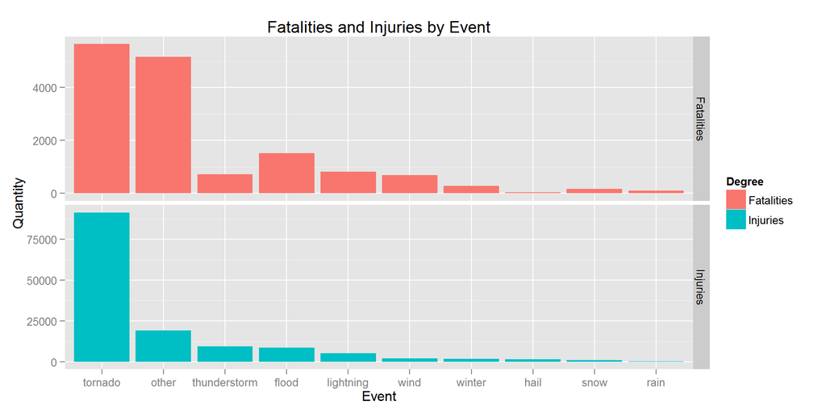

```r
storm.health <- storm.data %>%
  select(
    Event = event.type,
    Fatalities = health.fatalities,
    Injuries = health.injuries) %>%
  gather(
    key = Degree,
    value = Quantity,
    Fatalities:Injuries) %>%
  group_by(
    Event,
    Degree) %>%
  summarise(
    Quantity = sum(Quantity)) %>%
  group_by() %>%
  mutate(
    Event = as.factor(Event))

storm.health.order = storm.health %>%
  select(-Degree) %>%
  group_by(Event) %>%
  summarise(Quantity = sum(Quantity)) %>%
  arrange(desc(Quantity))

storm.health$Event = factor(storm.health$Event, levels = storm.health.order$Event[order(storm.health.order$Quantity, decreasing = TRUE)])

storm.health.chart <- ggplot(
  storm.health,
  aes(
    x = Event,
    y = Quantity,
    fill = Degree
    )
  ) +

  geom_bar(
    stat = "identity",
    position = "stack"
    ) +

  facet_grid(
    Degree ~ .,
    scales = 'free') +

  ggtitle("Fatalities and Injuries by Event")

print(storm.health.chart)
```

### Economic Impacts

To calculate economic impacts by event type, we perform a similar analysis, this time measuring Property and Crop Damages.

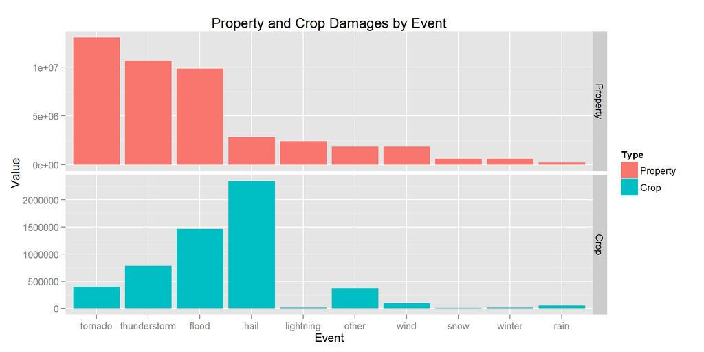

```r
storm.damage <- storm.data %>%
  select(
    Event = event.type,
    Property = economic.property.damage,
    Crop = economic.crop.damage) %>%
  gather(
    key = Type,
    value = Value,
    Property:Crop) %>%
  group_by(
    Event,
    Type) %>%
  summarise(
    Value = sum(Value)) %>%
  group_by() %>%
  mutate(
    Event = as.factor(Event))

storm.damage.order = storm.damage %>%
  select(-Type) %>%
  group_by(Event) %>%
  summarise(Value = sum(Value)) %>%
  arrange(desc(Value))

storm.damage$Event = factor(storm.damage$Event, levels = storm.damage.order$Event[order(storm.damage.order$Value, decreasing = TRUE)])

storm.damage.chart <- ggplot(
  storm.damage,
  aes(
    x = Event,
    y = Value,
    fill = Type
    )
  ) +

  geom_bar(
    stat = "identity"
    ) +

  facet_grid(
    Type ~ .,
    scales = 'free') +

  ggtitle("Property and Crop Damages by Event")

print(storm.damage.chart)
```

From the chart, we can conclude that Tornadoes, Thunderstorms and Floods are by far the greatest causes of damage economically.

These 3 are not the worst causes looking only at crop damage, where Hail seems to be the biggest culprit. However, property damage has much more of an economic impact than crop damage, as can be seen in the chart below.

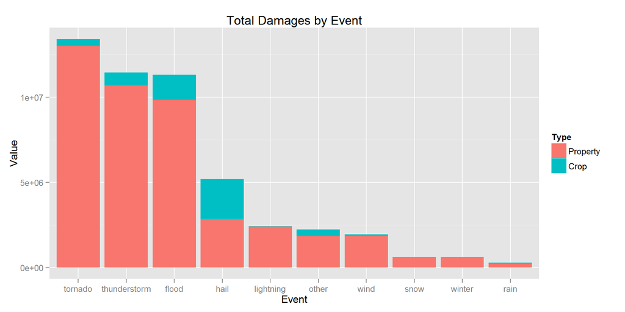

```r
storm.damage.chart2 <- ggplot(
  storm.damage,
  aes(
    x = Event,
    y = Value,
    fill = Type
    )
  ) +

  geom_bar(
    stat = "identity",
    position = "stack"
    ) +

  ggtitle("Total Damages by Event")
print(storm.damage.chart2)
```